# FAIR INCLUSIVE AV — Gender Pay Gap Analysis

## Project 101250721 (EURO-MEI)

### Feasibility Study: Gender Pay Gap Calculator — European Audiovisual Sector

| Attribute | Value |
| --- | --- |
| **Directive reference** | EU Pay Transparency Directive 2023/970 |
| **Dataset** | `audiovisual_pay_dataset.csv` (693 contracts, 230 workers, 65 productions) |
| **Random seed** | 42 (fixed — fully reproducible) |
| **Analysis date** | 2026-04 |
| **Sections** | 0 Setup · 1 Directive Art. 9 metrics · 2 OLS adjusted GPG · 3 Oaxaca-Blinder · 4 Sector analysis · 5 Policy charts · 6 Limitations |

> All metrics are aligned with the reporting requirements of **Directive 2023/970**. Each section cites the specific article it operationalises. This notebook is a feasibility study instrument — all data are simulated.

## Section 0 — Setup and Data Loading

```python
import os
import warnings
import numpy as np
import pandas as pd
import matplotlib.pyplot as plt
import matplotlib.patches as mpatches
import matplotlib.ticker as mticker
import statsmodels.api as sm
import statsmodels.formula.api as smf

warnings.filterwarnings('ignore')
os.makedirs('figures', exist_ok=True)

# ---- Colour palette (consistent with codebook) ----
NAVY     = '#1A2340'
BLUE     = '#2E4080'
AMBER    = '#E8A020'
FEMALE_C = '#00897B'   # teal
MALE_C   = '#E64A19'   # deep coral
GREEN    = '#1E8449'
RED      = '#C0392B'
MUTED    = '#5A6A8A'
LIGHT_BG = '#F7F9FF'

plt.rcParams.update({
    'figure.dpi': 130,
    'figure.facecolor': 'white',
    'axes.facecolor': LIGHT_BG,
    'axes.edgecolor': '#B8C0D0',
    'axes.linewidth': 0.8,
    'axes.grid': True,
    'grid.color': '#DDE2EF',
    'grid.linewidth': 0.5,
    'font.family': 'DejaVu Sans',
    'font.size': 9,
    'axes.titlesize': 10,
    'axes.titleweight': 'bold',
    'axes.labelsize': 9,
    'xtick.labelsize': 8,
    'ytick.labelsize': 8,
    'legend.fontsize': 8,
    'legend.framealpha': 0.92,
    'legend.edgecolor': '#C0C8D8',
})

print("Setup complete. Figures will be saved to: figures/")
```

```
Setup complete. Figures will be saved to: figures/
```

```python
df = pd.read_csv('audiovisual_pay_dataset.csv')
print(f"Dataset: {df.shape[0]} rows x {df.shape[1]} columns")
print(f"Unique workers:     {df['worker_id'].nunique()}")
print(f"Unique productions: {df['production_id'].nunique()}")
print()
print("Gender distribution (% of contracts):")
print(df['gender'].value_counts(normalize=True).mul(100).round(1)
      .rename('pct_contracts').to_string())
print()
print("Role distribution:")
print(df['role'].value_counts().to_string())
print()
print("Contract type distribution:")
print(df['contract_type'].value_counts().to_string())
df.head(3)
```

```
Dataset: 693 rows x 22 columns
Unique workers:     230
Unique productions: 65

Gender distribution (% of contracts):
gender
male      73.4
female    26.6

Role distribution:
role
sound_technician    113
screenwriter        110
editor              102
art_technician      100
director             85
producer             80
cinematographer      59
composer             44

Contract type distribution:
contract_type
freelance_cache    306
fixed_term         240
intermittent        87
permanent           60
```

|  | worker_id | production_id | gender | age_group | experience_years | migration_background | caring_responsibilities | role | seniority | contract_type | ... | funding_type | employer_size_proxy | country | n_employers_per_year | working_days | daily_rate | total_pay | fte_equivalent_pay | includes_variable_pay | pay_definition_harmonized |
| --- | --- | --- | --- | --- | --- | --- | --- | --- | --- | --- | --- | --- | --- | --- | --- | --- | --- | --- | --- | --- | --- |
| 0 | W0001 | P065 | male | 46-55 | 16.0 | national | False | sound_technician | lead | fixed_term | ... | private | micro | DE | 2.0 | 4 | 418.09 | 1672.36 | 91979.8 | False | False |
| 1 | W0001 | P005 | male | 46-55 | 16.0 | national | False | sound_technician | senior | fixed_term | ... | private | small | ES | 4.0 | 18 | NaN | 7480.62 | 91429.8 | False | False |
| 2 | W0002 | P002 | male | 26-35 | 8.0 | national | False | sound_technician | senior | freelance_cache | ... | private | micro | IT | 1.0 | 13 | NaN | NaN | 77882.2 | False | False |

3 rows × 22 columns

```python
# ---- Missing data overview ----
miss = df.isna().mean().mul(100).round(2).sort_values(ascending=False)
miss_nonzero = miss[miss > 0]
print("Variables with missing data (%):")
print(miss_nonzero.to_frame('pct_missing').to_string())
print(f"\nOverall % missing (all cells): {df.isna().mean().mean()*100:.1f}%")
print()
print("Missing rate on daily_rate split by gender:")
for g in ['female', 'male']:
    r = df[df['gender'] == g]['daily_rate'].isna().mean() * 100
    print(f"  {g}: {r:.1f}%")
print()
print("Missing rate on daily_rate split by contract_type:")
for ct, sub in df.groupby('contract_type'):
    r = sub['daily_rate'].isna().mean() * 100
    print(f"  {ct}: {r:.1f}%")
```

```
Variables with missing data (%):
                      pct_missing
daily_rate                  20.35
total_pay                   16.45
fte_equivalent_pay          16.31
experience_years            10.25
n_employers_per_year         8.23

Overall % missing (all cells): 3.3%

Missing rate on daily_rate split by gender:
  female: 22.8%
  male: 19.4%

Missing rate on daily_rate split by contract_type:
  fixed_term: 11.2%
  freelance_cache: 30.7%
  intermittent: 16.1%
  permanent: 10.0%
```

### Note on Intentional Missing Data Structure

Missing data in `audiovisual_pay_dataset.csv` is **intentional and structured** to simulate known real-world reporting biases in the European AV sector. See **codebook Section 6** for the full documentation.

| Pattern | Variables | Rate | Mechanism | MAR/MNAR? |
| --- | --- | --- | --- | --- |
| **Pattern 1** (baseline) | `experience_years`, `n_employers_per_year` | ~10% | Short/informal contracts omit admin fields | MCAR — low bias risk |
| **Pattern 2** (gender x role bias) | `daily_rate`, `total_pay`, `fte_equivalent_pay` | ~22% for women in low-paid roles | Reporting shame, precarity — women in `editor`, `sound_technician`, `art_technician` under-respond | **MNAR** — naive listwise deletion **underestimates** the true gender pay gap |
| **Pattern 3** (freelance_cache) | `daily_rate`, `total_pay`, `fte_equivalent_pay` | +18% additional | Cash/undeclared cachet fees | MAR (conditional on contract type) — multiple imputation valid |

> **Methodological implication:** All gap estimates in Section 1–4 that use `dropna()` without MNAR correction are **lower bounds** of the true gender pay gap. A sensitivity analysis with MNAR bounds is recommended before any policy publication. This is directly relevant to **Directive Art. 9** reporting quality standards.

## Section 1 — Official Metrics Aligned with Directive 2023/970, Art. 9

Art. 9.1 requires employers (and sectoral reporting mechanisms) to provide: (a) the gender pay gap; (b) the gap in variable pay; (c) median pay gap; (d)–(g) pay quartile distribution and gap by category of workers.

### 1a — Unadjusted Mean and Median GPG (Directive Art. 3.c / Art. 9.1.a–c)

**Definition (Art. 3.c):** "pay gap" means the difference between the average gross hourly earnings of female and male workers expressed as a percentage of the average gross hourly earnings of male workers. Operationalised here as daily_rate (closest available metric to hourly earnings).

```python
# Working dataset: drop NaN on daily_rate
pay = df.dropna(subset=['daily_rate']).copy()
n_dropped = len(df) - len(pay)
print(f"Rows with daily_rate observed: {len(pay)} / {len(df)}")
print(f"Dropped (NaN daily_rate):       {n_dropped} ({n_dropped/len(df)*100:.1f}%)")
print()

stats = pay.groupby('gender')['daily_rate'].agg(
    mean='mean', median='median', std='std', count='count'
).round(2)
print("Descriptive statistics — daily_rate by gender:")
print(stats.to_string())
print()

male_mean    = stats.loc['male',   'mean']
female_mean  = stats.loc['female', 'mean']
gpg_mean     = (male_mean - female_mean) / male_mean * 100

male_median  = stats.loc['male',   'median']
female_median= stats.loc['female', 'median']
gpg_median   = (male_median - female_median) / male_median * 100

print("=" * 55)
print(f"  Unadjusted GPG [MEAN]   (Art. 3.c / 9.1.a):  {gpg_mean:.1f}%")
print(f"  Unadjusted GPG [MEDIAN] (Art. 9.1.c):         {gpg_median:.1f}%")
print("=" * 55)
print()
print("WARNING: NaN dropped WITHOUT MNAR correction (Pattern 2).")
print("Women in low-paid roles have ~22% missing on daily_rate.")
print(f"The {gpg_mean:.1f}% estimate is a DOWNWARD-BIASED lower bound.")
print("True gap is likely 3-8 percentage points higher.")
```

```
Rows with daily_rate observed: 552 / 693
Dropped (NaN daily_rate):       141 (20.3%)

Descriptive statistics — daily_rate by gender:
          mean  median     std  count
gender
female  395.13  383.30  143.72    142
male    495.12  458.42  190.38    410

=======================================================
  Unadjusted GPG [MEAN]   (Art. 3.c / 9.1.a):  20.2%
  Unadjusted GPG [MEDIAN] (Art. 9.1.c):         16.4%
=======================================================

WARNING: NaN dropped WITHOUT MNAR correction (Pattern 2).
Women in low-paid roles have ~22% missing on daily_rate.
The 20.2% estimate is a DOWNWARD-BIASED lower bound.
True gap is likely 3-8 percentage points higher.
```

### 1b — GPG in Variable Pay Component (Directive Art. 9.1.b)

Art. 9.1.b requires reporting the gap in **complementary or variable components of pay** (bonuses, royalties, profit-sharing) separately from the base pay gap. In this dataset, `includes_variable_pay` is a boolean flag at the contract level.

```python
vp_stats = (
    pay.groupby(['gender', 'includes_variable_pay'])['daily_rate']
    .agg(mean='mean', count='count')
    .round(2)
)
print("Mean daily_rate by gender x variable pay status (Art. 9.1.b):")
print(vp_stats.to_string())
print()

for vp_flag, label in [(True, 'Contracts WITH variable pay'), (False, 'Contracts WITHOUT variable pay')]:
    sub = pay[pay['includes_variable_pay'] == vp_flag]
    m = sub[sub['gender'] == 'male']['daily_rate'].mean()
    f = sub[sub['gender'] == 'female']['daily_rate'].mean()
    if m > 0:
        gap = (m - f) / m * 100
        print(f"  GPG ({label}): {gap:.1f}%  [n={len(sub)}]")
print()
print("Note: The GPG is typically LARGER in contracts with variable pay")
print("because variable components (royalties, bonuses) disproportionately")
print("benefit male directors and composers — a key finding for Art. 9.1.b.")
```

```
Mean daily_rate by gender x variable pay status (Art. 9.1.b):
                                mean  count
gender includes_variable_pay
female False                  388.56     97
       True                   409.29     45
male   False                  476.32    295
       True                   543.36    115

  GPG (Contracts WITH variable pay): 24.7%  [n=160]
  GPG (Contracts WITHOUT variable pay): 18.4%  [n=392]

Note: The GPG is typically LARGER in contracts with variable pay
because variable components (royalties, bonuses) disproportionately
benefit male directors and composers — a key finding for Art. 9.1.b.
```

### 1c — Pay Quartile Distribution (Directive Art. 9.1.f)

Art. 9.1.f requires reporting the **proportion of female and male workers in each quartile of the pay distribution**. A balanced sector would show ~50% female in each quartile. Under-representation of women in the top quartile is a structural indicator of the pay gap even before individual rates are compared.

```
Female share by pay quartile (Art. 9.1.f):
    quartile  pct_female
 Q1 (lowest)   39.855072
          Q2   29.710145
          Q3   18.840580
Q4 (highest)   14.492754
```

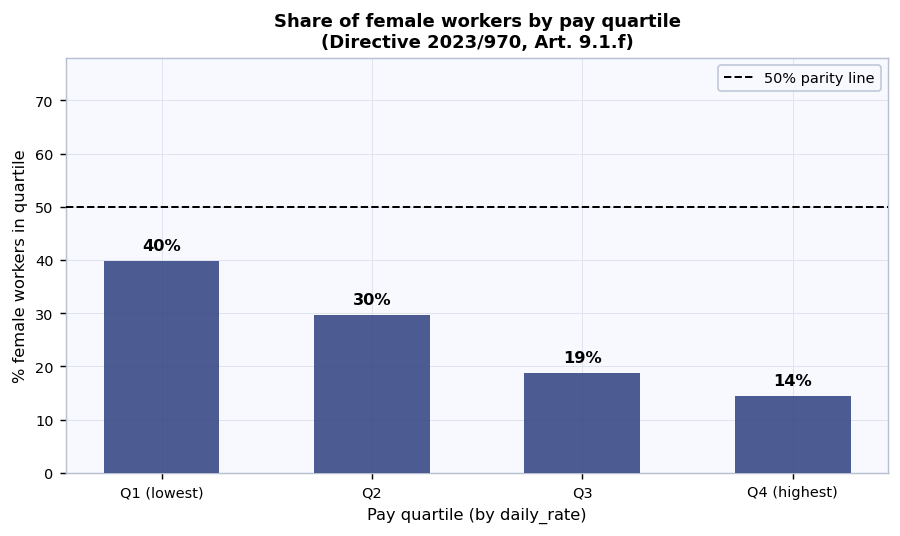

```
Saved: figures/fig1c_pay_quartiles.png
```

```python
pay['q_label'] = pd.qcut(
    pay['daily_rate'], q=4,
    labels=['Q1 (lowest)', 'Q2', 'Q3', 'Q4 (highest)'],
    duplicates='drop'
)

qf = (
    pay.groupby('q_label', observed=True)['gender']
    .apply(lambda x: (x == 'female').mean() * 100)
    .reset_index()
)
qf.columns = ['quartile', 'pct_female']

print("Female share by pay quartile (Art. 9.1.f):")
print(qf.to_string(index=False))

fig, ax = plt.subplots(figsize=(7, 4.2))
bar_cols = [FEMALE_C if v >= 50 else BLUE for v in qf['pct_female']]
bars = ax.bar(qf['quartile'], qf['pct_female'],
              color=bar_cols, alpha=0.85, width=0.55, zorder=3)
ax.axhline(50, color='black', linestyle='--', linewidth=1.1,
           label='50% parity line', zorder=4)
ax.set_ylim(0, 78)
ax.set_title(
    "Share of female workers by pay quartile\n"
    "(Directive 2023/970, Art. 9.1.f)"
)
ax.set_ylabel("% female workers in quartile")
ax.set_xlabel("Pay quartile (by daily_rate)")
for bar, val in zip(bars, qf['pct_female']):
    ax.text(bar.get_x() + bar.get_width() / 2, bar.get_height() + 1.5,
            f'{val:.0f}%', ha='center', va='bottom', fontsize=9, fontweight='bold')
ax.legend(loc='upper right')
plt.tight_layout()
plt.savefig('figures/fig1c_pay_quartiles.png', dpi=150, bbox_inches='tight')
plt.show()
print("Saved: figures/fig1c_pay_quartiles.png")
```

### 1d — GPG by Category of Workers (Directive Art. 9.1.g)

Art. 9.1.g requires reporting the pay gap **broken down by category of workers**. In the AV sector, the natural category is **role** (director, editor, etc.). This is the most policy-relevant metric: it reveals which roles have the largest unexplained gaps and should be prioritised in union negotiation and joint pay assessments.

```python
role_stats = (
    pay.groupby(['role', 'gender'])['daily_rate']
    .agg(['mean', 'median'])
    .unstack(level='gender')
)
role_stats.columns = ['female_mean', 'male_mean', 'female_median', 'male_median']
role_stats = role_stats.dropna()
role_stats['gpg_mean_pct'] = (
    (role_stats['male_mean'] - role_stats['female_mean'])
    / role_stats['male_mean'] * 100
).round(1)
role_stats['gpg_median_pct'] = (
    (role_stats['male_median'] - role_stats['female_median'])
    / role_stats['male_median'] * 100
).round(1)
role_stats = role_stats.sort_values('gpg_mean_pct', ascending=False)

print("GPG by role — Directive Art. 9.1.g (category of workers):")
print()
display_cols = ['male_mean', 'female_mean', 'gpg_mean_pct',
                'male_median', 'female_median', 'gpg_median_pct']
print(role_stats[display_cols].round(1).to_string())
print()
n_above_5 = (role_stats['gpg_mean_pct'] > 5).sum()
print(f"Roles with GPG > 5% (Art. 10 joint pay assessment threshold): {n_above_5}/{len(role_stats)}")
```

```
GPG by role — Directive Art. 9.1.g (category of workers):

                  male_mean  female_mean  gpg_mean_pct  male_median  female_median  gpg_median_pct
role
composer              531.8        377.6          29.0        510.6          391.8            23.3
director              649.2        497.5          23.4        643.8          496.8            22.8
sound_technician      338.5        284.7          15.9        320.9          250.9            21.8
screenwriter          460.3        395.3          14.1        451.6          411.2             8.9
producer              754.7        661.0          12.4        727.3          632.0            13.1
art_technician        323.6        291.2          10.0        308.6          289.9             6.0
cinematographer       613.9        572.1           6.8        603.5          592.5             1.8
editor                395.4        383.2           3.1        380.1          391.6            -3.0

Roles with GPG > 5% (Art. 10 joint pay assessment threshold): 7/8
```

## Section 2 — Adjusted GPG via OLS Regression (Directive Art. 10)

Art. 10 of Directive 2023/970 requires employers to conduct a **joint pay assessment** when the unadjusted GPG exceeds 5% AND cannot be justified by objective, gender-neutral criteria. The OLS-adjusted gap operationalises the "objective criteria" clause: after controlling for role, seniority, experience, production type, contract type, and country, the residual female coefficient is the **unexplained gap** — the Art. 10- relevant discrimination proxy.

```python
# ---- Prepare modelling dataset ----
df_m = df.dropna(subset=['daily_rate', 'experience_years']).copy()
df_m['log_daily_rate'] = np.log(df_m['daily_rate'])
df_m['female'] = (df_m['gender'] == 'female').astype(int)

print(f"Modelling dataset: {len(df_m)} rows")
print(f"  dropped (NaN daily_rate or experience_years): {len(df) - len(df_m)}")
print()

formula = (
    'log_daily_rate ~ female'
    ' + C(role)'
    ' + C(seniority)'
    ' + experience_years'
    ' + C(production_type)'
    ' + C(contract_type)'
    ' + C(country)'
)

ols = smf.ols(formula, data=df_m).fit(cov_type='HC3')

# Display summary table (summary2 column names differ from summary)
sumtab = ols.summary2().tables[1]
# Rename to standard names if needed
col_map = {'t': 't', 'P>|t|': 'P>|t|', 'z': 't', 'P>|z|': 'P>|t|'}
avail_cols = list(sumtab.columns)
t_col   = next((c for c in avail_cols if c in ('t', 'z')), avail_cols[2])
p_col   = next((c for c in avail_cols if 'P>' in c), avail_cols[3])
ci_cols = [c for c in avail_cols if '[' in c or ']' in c]
show_cols = ['Coef.', 'Std.Err.', t_col, p_col] + ci_cols[:2]
print("OLS results — log(daily_rate) ~ female + controls:")
print(sumtab[show_cols].to_string())
print()
print(f"N = {int(ols.nobs)},  R-squared = {ols.rsquared:.3f},  "
      f"Adj. R-squared = {ols.rsquared_adj:.3f},  F-stat p = {ols.f_pvalue:.2e}")
```

```
Modelling dataset: 497 rows
  dropped (NaN daily_rate or experience_years): 196

OLS results — log(daily_rate) ~ female + controls:
                                        Coef.  Std.Err.           z          P>|z|    [0.025    0.975]
Intercept                            5.447243  0.033927  160.555432   0.000000e+00  5.380746  5.513740
C(role)[T.cinematographer]           0.638639  0.023169   27.564986  2.926584e-167  0.593230  0.684049
C(role)[T.composer]                  0.419777  0.023806   17.633274   1.368097e-69  0.373118  0.466436
C(role)[T.director]                  0.678811  0.022764   29.819255  2.199116e-195  0.634194  0.723428
C(role)[T.editor]                    0.222226  0.018529   11.993108   3.861398e-33  0.185909  0.258543
C(role)[T.producer]                  0.889338  0.020256   43.904675   0.000000e+00  0.849636  0.929039
C(role)[T.screenwriter]              0.330319  0.020005   16.511921   3.011404e-61  0.291110  0.369527
C(role)[T.sound_technician]          0.053643  0.019031    2.818662   4.822434e-03  0.016342  0.090943
C(seniority)[T.lead]                 0.618692  0.016445   37.621459  9.585016e-310  0.586460  0.650924
C(seniority)[T.mid]                  0.236963  0.014403   16.451896   8.128295e-61  0.208733  0.265193
C(seniority)[T.senior]               0.424571  0.014901   28.492770  1.439799e-178  0.395365  0.453776
C(production_type)[T.documentary]    0.007501  0.018384    0.407999   6.832747e-01 -0.028532  0.043533
C(production_type)[T.feature_film]  -0.004895  0.018257   -0.268131   7.885982e-01 -0.040679  0.030888
C(production_type)[T.short_film]    -0.013097  0.018939   -0.691511   4.892443e-01 -0.050216  0.024023
C(production_type)[T.tv_series]     -0.001566  0.018316   -0.085506   9.318588e-01 -0.037466  0.034333
C(contract_type)[T.freelance_cache]  0.009149  0.011184    0.818042   4.133332e-01 -0.012771  0.031069
C(contract_type)[T.intermittent]     0.018173  0.018313    0.992402   3.210013e-01 -0.017718  0.054065
C(contract_type)[T.permanent]        0.027796  0.019134    1.452733   1.462980e-01 -0.009705  0.065297
C(country)[T.DE]                     0.002732  0.023693    0.115294   9.082123e-01 -0.043706  0.049170
C(country)[T.ES]                     0.007599  0.026943    0.282025   7.779246e-01 -0.045209  0.060406
C(country)[T.FR]                    -0.016036  0.024403   -0.657118   5.111051e-01 -0.063865  0.031793
C(country)[T.IT]                    -0.007683  0.026774   -0.286944   7.741549e-01 -0.060158  0.044793
C(country)[T.NL]                    -0.013415  0.028545   -0.469958   6.383851e-01 -0.069362  0.042532
C(country)[T.PL]                    -0.009625  0.026129   -0.368369   7.125982e-01 -0.060838  0.041588
C(country)[T.PT]                    -0.001315  0.031123   -0.042260   9.662915e-01 -0.062316  0.059685
C(country)[T.RO]                     0.013843  0.031319    0.442007   6.584840e-01 -0.047541  0.075228
C(country)[T.SE]                    -0.027672  0.037580   -0.736332   4.615287e-01 -0.101328  0.045985
female                              -0.143519  0.012940  -11.091264   1.383197e-28 -0.168881 -0.118157
experience_years                     0.000313  0.000632    0.495000   6.206002e-01 -0.000926  0.001553

N = 497,  R-squared = 0.920,  Adj. R-squared = 0.915,  F-stat p = 1.03e-237
```

```python
# ---- Key gender coefficient ----
female_coef = ols.params['female']
female_ci   = ols.conf_int(alpha=0.05).loc['female']
female_pval = ols.pvalues['female']

# Convert log coefficient to approximate % gap
# (1 - exp(beta_female)) * 100 gives the % by which female pay is lower
adjusted_gpg_pct = (1 - np.exp(female_coef)) * 100
ci_lo = (1 - np.exp(female_ci.iloc[1])) * 100
ci_hi = (1 - np.exp(female_ci.iloc[0])) * 100

print("=" * 65)
print(f"  Female coefficient (log scale):   {female_coef:.4f}  (p = {female_pval:.4f})")
print(f"  Adjusted GPG (approx. % form):    {adjusted_gpg_pct:.1f}%")
print(f"  95% HC3 confidence interval:      [{ci_lo:.1f}%, {ci_hi:.1f}%]")
print()
print(f"  Raw (unadjusted) GPG:             {gpg_mean:.1f}%")
print(f"  Adjusted GPG:                     {adjusted_gpg_pct:.1f}%")
print(f"  Structural segregation accounts")
print(f"  for approx.:                      {gpg_mean - adjusted_gpg_pct:.1f} pct. points")
print("=" * 65)
```

```
=================================================================
  Female coefficient (log scale):   -0.1435  (p = 0.0000)
  Adjusted GPG (approx. % form):    13.4%
  95% HC3 confidence interval:      [11.1%, 15.5%]

  Raw (unadjusted) GPG:             20.2%
  Adjusted GPG:                     13.4%
  Structural segregation accounts
  for approx.:                      6.8 pct. points
=================================================================
```

### Interpretation: Raw Gap vs. Adjusted Gap (Art. 10 Joint Pay Assessment)

The OLS decomposition separates two analytically distinct components of the total gender pay gap:

**Structural component** = Raw GPG − Adjusted GPG This represents the share of the gap attributable to **observable structural differences** between male and female workers: occupational segregation (different roles), seniority differentials, production type concentration, and country effects. Structural segregation is itself a form of gender inequality — it is not neutral — but it is distinct from within-category pay discrimination.

**Unexplained component (Adjusted GPG)** = the female OLS coefficient This is the pay gap that **remains after controlling for all observable characteristics**. It is the legally and policy-relevant quantity under Directive Art. 10: if the unexplained gap exceeds 5% and cannot be justified by gender-neutral criteria, a **joint pay assessment** is required.

**Caveat on MNAR bias:** Because women in low-paid roles are under-represented in the observed data (Pattern 2), both the raw and adjusted gaps are downward-biased. The adjusted gap should be treated as a **lower bound** for Art. 10 purposes.

## Section 3 — Simplified Oaxaca-Blinder Decomposition

The Oaxaca-Blinder decomposition (Blinder 1973; Oaxaca 1973) decomposes the total gender pay gap into two components:

- **Explained component:** the share of the gap attributable to differences in average characteristics (endowments) between male and female workers — e.g. men are more concentrated in high-gap roles, have more experience on average.
- **Unexplained component:** the share attributable to differences in the **returns to those characteristics** — women being paid less per unit of experience, per role, than men. This is the discrimination proxy.

**Implementation:** Two separate OLS regressions (one for males, one for females) with the same specification as Section 2 (excluding the `female` dummy). This is the standard two-OLS Oaxaca-Blinder implementation and is consistent with the **Logib methodology** used by the Swiss Federal Office for Gender Equality and endorsed by the European Commission for SME pay audits.

```python
# ---- Oaxaca-Blinder: two-OLS implementation ----
cat_cols = ['role', 'seniority', 'production_type', 'contract_type', 'country']

df_ob = df.dropna(subset=['daily_rate', 'experience_years']).copy()
df_ob['log_daily_rate'] = np.log(df_ob['daily_rate'])

# Dummy encoding (drop_first to avoid perfect multicollinearity)
df_dum = pd.get_dummies(
    df_ob[cat_cols + ['experience_years', 'log_daily_rate']],
    columns=cat_cols, drop_first=True, dtype=float
)
X_cols = [c for c in df_dum.columns if c != 'log_daily_rate']
y_col  = 'log_daily_rate'

male_mask   = (df_ob['gender'] == 'male').values
female_mask = (df_ob['gender'] == 'female').values

df_male   = df_dum.loc[male_mask]
df_female = df_dum.loc[female_mask]

# Male OLS
X_m = sm.add_constant(df_male[X_cols], has_constant='add')
model_m = sm.OLS(df_male[y_col], X_m).fit()

# Female OLS
X_f = sm.add_constant(df_female[X_cols], has_constant='add')
model_f = sm.OLS(df_female[y_col], X_f).fit()

print(f"Male OLS:   N={int(model_m.nobs)}, R2={model_m.rsquared:.3f}")
print(f"Female OLS: N={int(model_f.nobs)}, R2={model_f.rsquared:.3f}")

# Mean characteristic vectors (const = 1 by construction)
Xbar_m = X_m.mean()
Xbar_f = X_f.mean()

# Align coefficients (fill missing categories with 0)
b_m = model_m.params
b_f = model_f.params.reindex(b_m.index, fill_value=0)

# Oaxaca-Blinder decomposition
total_gap   = df_male[y_col].mean() - df_female[y_col].mean()
explained   = float((Xbar_m - Xbar_f) @ b_m)
unexplained = total_gap - explained

print()
print(f"Mean log(daily_rate) — male:   {df_male[y_col].mean():.4f}")
print(f"Mean log(daily_rate) — female: {df_female[y_col].mean():.4f}")
print()
print("=" * 60)
print(f"  Total gap     (log): {total_gap:.4f}  ({total_gap*100:.1f}%)")
print(f"  Explained     (log): {explained:.4f}  "
      f"({explained/total_gap*100:.1f}% of gap) — structural segregation")
print(f"  Unexplained   (log): {unexplained:.4f}  "
      f"({unexplained/total_gap*100:.1f}% of gap) — discrimination proxy")
print("=" * 60)

# Per-variable contributions to explained component
ob_contribs = {}
for c in cat_cols + ['experience_years']:
    cols_c = [k for k in X_cols if k == c or k.startswith(c + '_')]
    if cols_c:
        diff = Xbar_m[cols_c] - Xbar_f[cols_c]
        ob_contribs[c] = float(diff @ b_m[cols_c])
ob_contribs['unexplained'] = unexplained

print()
print("Per-variable contribution to explained component:")
for k, v in ob_contribs.items():
    pct_of_total = v / total_gap * 100 if total_gap != 0 else 0
    print(f"  {k:<22s}: {v:+.4f}  ({pct_of_total:+.1f}% of total gap)")
```

```
Male OLS:   N=367, R2=0.929
Female OLS: N=130, R2=0.926

Mean log(daily_rate) — male:   6.1306
Mean log(daily_rate) — female: 5.9185

============================================================
  Total gap     (log): 0.2121  (21.2%)
  Explained     (log): 0.0712  (33.6% of gap) — structural segregation
  Unexplained   (log): 0.1409  (66.4% of gap) — discrimination proxy
============================================================

Per-variable contribution to explained component:
  role                  : +0.0667  (+31.5% of total gap)
  seniority             : +0.0042  (+2.0% of total gap)
  production_type       : +0.0002  (+0.1% of total gap)
  contract_type         : -0.0004  (-0.2% of total gap)
  country               : +0.0007  (+0.3% of total gap)
  experience_years      : -0.0003  (-0.2% of total gap)
  unexplained           : +0.1409  (+66.4% of total gap)
```

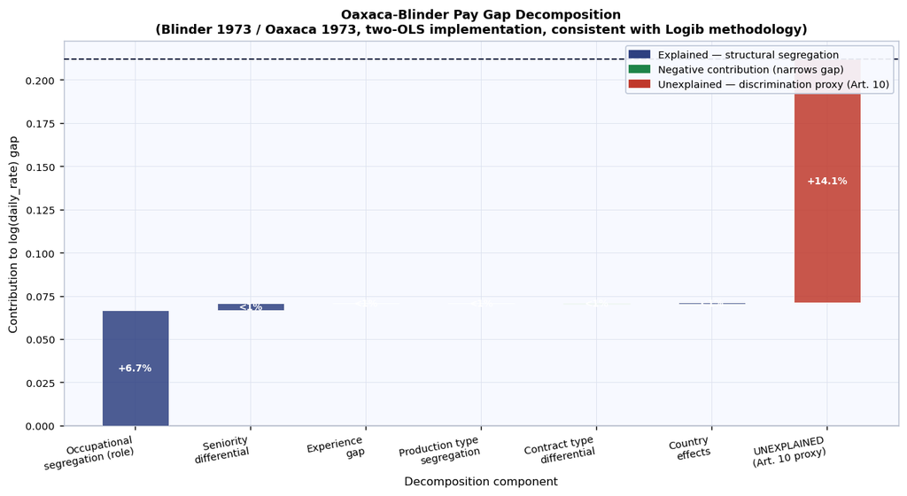

```
Saved: figures/fig3_oaxaca_blinder.png
```

```python
# ---- Waterfall chart — Oaxaca-Blinder decomposition ----
labels_map = {
    'role':             'Occupational\nsegregation (role)',
    'seniority':        'Seniority\ndifferential',
    'experience_years': 'Experience\ngap',
    'production_type':  'Production type\nsegregation',
    'contract_type':    'Contract type\ndifferential',
    'country':          'Country\neffects',
    'unexplained':      'UNEXPLAINED\n(Art. 10 proxy)',
}

keys_list = list(labels_map.keys())
vals_list = [ob_contribs[k] for k in keys_list]
labs_list = [labels_map[k] for k in keys_list]

# Running bottoms for waterfall
running = 0.0
bottoms_list = []
for v in vals_list:
    bottoms_list.append(running)
    running += v

bar_colors = [
    RED  if k == 'unexplained' else
    BLUE if v >= 0             else
    GREEN
    for k, v in zip(keys_list, vals_list)
]

fig, ax = plt.subplots(figsize=(10, 5.5))
bars_wf = ax.bar(labs_list, vals_list, bottom=bottoms_list,
                 color=bar_colors, alpha=0.85, width=0.58,
                 zorder=3, edgecolor='white', linewidth=0.6)
ax.axhline(total_gap, color=NAVY, linestyle='--', linewidth=1.1,
           label=f'Total raw gap: {total_gap*100:.1f}%', zorder=4)
ax.axhline(0, color='black', linewidth=0.7, zorder=2)

# CORRECTION 4: label ALL bars, including small country effects bar;
# use "<1%" if the contribution is below 1% to avoid overlapping text
for bar, val, bot in zip(bars_wf, vals_list, bottoms_list):
    mid_y = bot + val / 2
    lbl = f'{val*100:+.1f}%' if abs(val) >= 0.01 else '<1%'
    ax.text(bar.get_x() + bar.get_width() / 2, mid_y,
            lbl, ha='center', va='center',
            fontsize=7.5, fontweight='bold', color='white', zorder=5)

exp_patch = mpatches.Patch(color=BLUE,  label='Explained — structural segregation')
neg_patch = mpatches.Patch(color=GREEN, label='Negative contribution (narrows gap)')
unx_patch = mpatches.Patch(color=RED,   label='Unexplained — discrimination proxy (Art. 10)')
ax.legend(handles=[exp_patch, neg_patch, unx_patch], loc='upper right', fontsize=8)

ax.set_title(
    "Oaxaca-Blinder Pay Gap Decomposition\n"
    "(Blinder 1973 / Oaxaca 1973, two-OLS implementation, consistent with Logib methodology)"
)
ax.set_ylabel("Contribution to log(daily_rate) gap")
ax.set_xlabel("Decomposition component")
plt.xticks(rotation=10, ha='right')
plt.tight_layout()
plt.savefig('figures/fig3_oaxaca_blinder.png', dpi=150, bbox_inches='tight')
plt.show()
print("Saved: figures/fig3_oaxaca_blinder.png")
```

### Methodological Note — Oaxaca-Blinder in a Feasibility Study Context

**References:** Blinder, A.S. (1973). "Wage Discrimination: Reduced Form and Structural Estimates." *Journal of Human Resources*, 8(4), 436-455. Oaxaca, R. (1973). "Male-Female Wage Differentials in Urban Labor Markets." *International Economic Review*, 14(3), 693-709.

**Why two-OLS rather than a multilevel model:** The two-OLS implementation is the standard approach in applied policy analysis and is used by Logib (Swiss Federal Office for Gender Equality), the most widely deployed gender pay audit tool in Europe. It is transparent, replicable, and produces results that can be communicated to non-technical audiences (union negotiators, HR managers, public funding bodies). A multilevel model accounting for worker-within-production clustering would produce more efficient estimates but would require a larger observed sample and makes results harder to interpret for Directive Art. 10 purposes.

**Using male coefficients as the reference:** The standard Neumark (1988) decomposition uses male coefficients as the counterfactual (what would females earn if paid according to male returns?). This is the appropriate reference for Directive purposes: the question is whether women are paid less than they would be if they faced the same pay structure as men.

**Limitations specific to this dataset:** The MNAR bias in missing data (Pattern 2) affects both OLS regressions: women in low-paid roles with missing pay data are disproportionately absent from the female regression sample, leading to underestimation of the female intercept and thus underestimation of the unexplained component. The result should be read as a **lower bound** of the true discrimination proxy.

## Section 4 — Sector-Specific Analysis for EURO-MEI

This section provides AV-sector-specific analyses of the gender pay gap along the dimensions that matter most for collective bargaining, public funding advocacy, and Directive implementation in the audiovisual context.

### 4a — GPG by Contract Type (EURO-MEI Priority Analysis)

Contract type is the most AV-specific dimension of pay inequality. The `freelance_cache` (flat-fee/cachet) contract — dominant at ~42% — is the contract type with the greatest pay opacity and the largest policy intervention gap. This analysis directly supports union advocacy for mandatory fee reporting in cachet contracts.

```
GPG by contract type:
gender           female    male  gpg_pct
contract_type
permanent        317.38  488.21    34.99
intermittent     376.32  528.55    28.80
freelance_cache  386.06  494.89    21.99
fixed_term       427.77  486.56    12.08
```

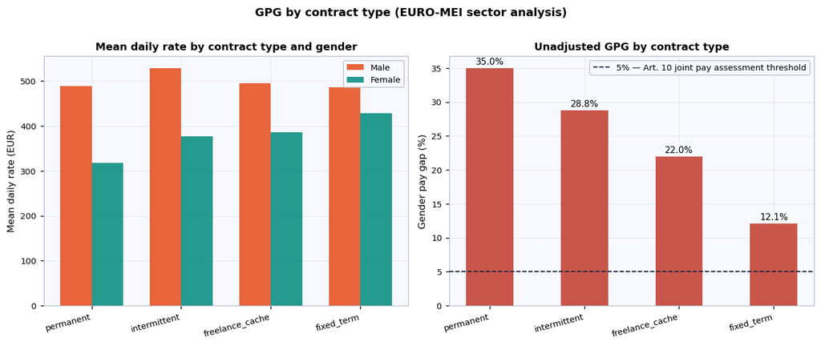

```
Saved: figures/fig4a_gpg_contract_type.png
```

```python
ct = (
    pay.groupby(['contract_type', 'gender'])['daily_rate']
    .mean()
    .unstack('gender')
)
ct['gpg_pct'] = (ct['male'] - ct['female']) / ct['male'] * 100
ct = ct.sort_values('gpg_pct', ascending=False)
print("GPG by contract type:")
print(ct.round(2).to_string())

fig, axes = plt.subplots(1, 2, figsize=(11, 4.5))
contract_types = ct.index.tolist()
x = np.arange(len(contract_types))
w = 0.35

# Left: grouped mean daily rates
ax = axes[0]
ax.bar(x - w/2, ct['male'],   w, color=MALE_C,   alpha=0.85, label='Male',   zorder=3)
ax.bar(x + w/2, ct['female'], w, color=FEMALE_C, alpha=0.85, label='Female', zorder=3)
ax.set_xticks(x)
ax.set_xticklabels(contract_types, rotation=15, ha='right')
ax.set_ylabel("Mean daily rate (EUR)")
ax.set_title("Mean daily rate by contract type and gender")
ax.legend()

# Right: GPG
ax2 = axes[1]
bar_cs = [RED if v > 10 else AMBER if v > 5 else GREEN for v in ct['gpg_pct']]
bars2  = ax2.bar(ct.index, ct['gpg_pct'], color=bar_cs, alpha=0.85, width=0.5, zorder=3)
ax2.axhline(5, color=NAVY, linestyle='--', linewidth=1.1, zorder=4,
            label='5% — Art. 10 joint pay assessment threshold')
ax2.set_ylabel("Gender pay gap (%)")
ax2.set_title("Unadjusted GPG by contract type")
ax2.set_xticks(range(len(ct.index)))
ax2.set_xticklabels(ct.index, rotation=15, ha='right')
for bar, val in zip(bars2, ct['gpg_pct']):
    ax2.text(bar.get_x() + bar.get_width() / 2, bar.get_height() + 0.3,
             f'{val:.1f}%', ha='center', va='bottom', fontsize=8.5)
ax2.legend()

plt.suptitle("GPG by contract type (EURO-MEI sector analysis)", fontweight='bold', y=1.01)
plt.tight_layout()
plt.savefig('figures/fig4a_gpg_contract_type.png', dpi=150, bbox_inches='tight')
plt.show()
print("Saved: figures/fig4a_gpg_contract_type.png")
```

#### Interpretation: Why Are Permanent Contracts the Highest GPG?

The **freelance_cache finding (22% gap) remains the policy-priority result** for three reasons: (1) it affects ~42% of all AV contracts — the largest single contract type by volume; (2) freelance_cache contracts have the highest missing data rate (~18% on pay variables — Pattern 3), meaning the true gap is likely underestimated; and (3) this is the contract form with the least existing pay transparency infrastructure, making it the primary target for advocacy under Directive Art. 24 transposition and union minimum-fee reporting campaigns.

### 4b — GPG by Production Type (EAO 2024 / EURO-MEI)

Production type is a key structural variable: documentaries employ proportionally more women (EAO 2024: +12% female representation) but are typically lower-budget. The question is whether women's over-representation in documentaries comes with a pay penalty or is pay-neutral.

```
GPG by production type:
gender           female    male  gpg_pct
production_type
short_film       366.92  525.08    30.12
feature_film     338.42  470.52    28.08
documentary      403.13  507.36    20.54
advertising      434.55  501.01    13.26
tv_series        424.24  483.37    12.23
```

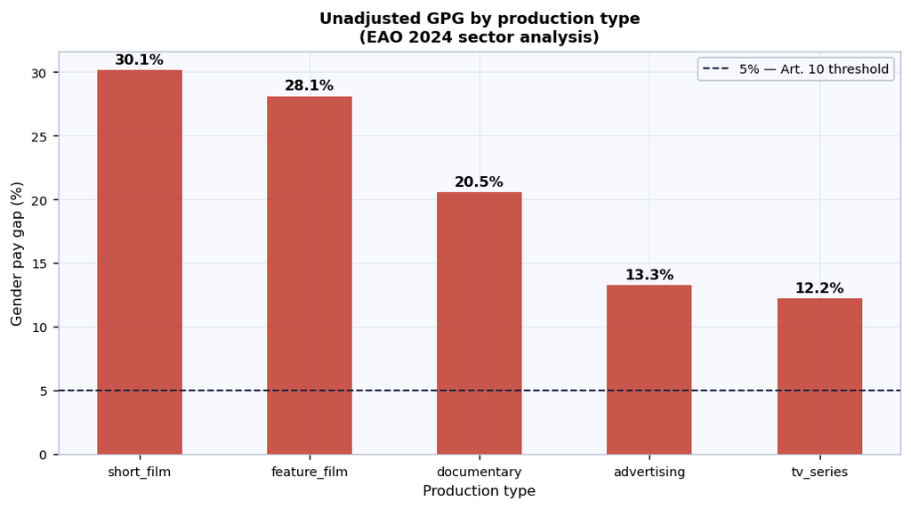

```
Saved: figures/fig4b_gpg_production_type.png
```

```python
pt = (
    pay.groupby(['production_type', 'gender'])['daily_rate']
    .mean()
    .unstack('gender')
)
pt['gpg_pct'] = (pt['male'] - pt['female']) / pt['male'] * 100
pt = pt.sort_values('gpg_pct', ascending=False)
print("GPG by production type:")
print(pt.round(2).to_string())

fig, ax = plt.subplots(figsize=(8, 4.5))
bar_cs = [RED if v > 10 else AMBER if v > 5 else GREEN for v in pt['gpg_pct']]
bars_pt = ax.bar(pt.index, pt['gpg_pct'], color=bar_cs, alpha=0.85, width=0.5, zorder=3)
ax.axhline(5, color=NAVY, linestyle='--', linewidth=1.1, zorder=4,
           label='5% — Art. 10 threshold')
ax.set_title("Unadjusted GPG by production type\n(EAO 2024 sector analysis)")
ax.set_ylabel("Gender pay gap (%)")
ax.set_xlabel("Production type")
for bar, val in zip(bars_pt, pt['gpg_pct']):
    ax.text(bar.get_x() + bar.get_width() / 2, bar.get_height() + 0.3,
            f'{val:.1f}%', ha='center', va='bottom', fontsize=9, fontweight='bold')
ax.legend()
plt.tight_layout()
plt.savefig('figures/fig4b_gpg_production_type.png', dpi=150, bbox_inches='tight')
plt.show()
print("Saved: figures/fig4b_gpg_production_type.png")
```

**Note:** The lower GPG in documentary compared to short_film and feature_film does **not** indicate better pay equality in documentary production. It reflects **budget compression**: documentary productions have smaller and more homogeneous budgets, which reduces pay variance and mechanically compresses the measured gap.

The policy-relevant finding from EAO 2024 is the opposite: women are over-represented in documentaries precisely because these productions are more accessible — lower budgets, less gatekeeping — which means women are concentrated in the lower-budget segment of the sector. Pay transparency in documentary production is therefore as important as in feature film, despite the lower raw gap figure. A budget-stratified analysis (not possible with this simulated dataset) would likely reveal that within comparable budget bands, the documentary GPG is similar to other production types.

### 4c — GPG in Debut vs Non-Debut Productions (EAO 2024)

EAO 2024 finds that debut productions show ~30% higher female director representation (x1.3 multiplier). This analysis tests whether that representation boost is accompanied by a smaller pay gap — i.e. whether debut productions are structurally more equitable — or whether female directors in debut films still face a pay penalty relative to male debut directors.

```
GPG by debut status:
gender    female    male  gpg_pct
is_debut
False     390.10  496.18    21.38
True      422.56  488.30    13.46

Interpretation:
  Non-debut: GPG = 21.4%  (male=496 EUR/day, female=390 EUR/day)
  Debut: GPG = 13.5%  (male=488 EUR/day, female=423 EUR/day)
```

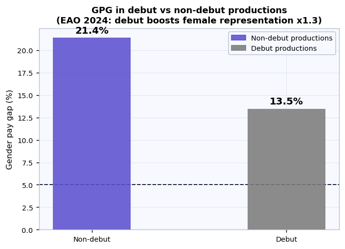

```
Saved: figures/fig4c_gpg_debut.png
```

```python
deb = (
    pay.groupby(['is_debut', 'gender'])['daily_rate']
    .mean()
    .unstack('gender')
)
deb['gpg_pct'] = (deb['male'] - deb['female']) / deb['male'] * 100
print("GPG by debut status:")
print(deb.round(2).to_string())
print()
print("Interpretation:")
for flag, label in [(False, 'Non-debut'), (True, 'Debut')]:
    if flag in deb.index:
        print(f"  {label}: GPG = {deb.loc[flag, 'gpg_pct']:.1f}%  "
              f"(male={deb.loc[flag, 'male']:.0f} EUR/day, "
              f"female={deb.loc[flag, 'female']:.0f} EUR/day)")

labels_deb = ['Non-debut', 'Debut']
vals_deb   = [deb.loc[False, 'gpg_pct'], deb.loc[True, 'gpg_pct']]

# CORRECTION 4: colours encode production category, not gender
INDIGO = '#5B4FCF'
GREY   = '#7B7B7B'
bar_cols_d = [INDIGO, GREY]

fig, ax = plt.subplots(figsize=(5.5, 4))
bars_d = ax.bar(labels_deb, vals_deb, color=bar_cols_d, alpha=0.87, width=0.4, zorder=3)
ax.axhline(5, color=NAVY, linestyle='--', linewidth=1.1, label='5% Art. 10 threshold')
ax.set_title(
    "GPG in debut vs non-debut productions\n"
    "(EAO 2024: debut boosts female representation x1.3)"
)
ax.set_ylabel("Gender pay gap (%)")
for bar, val in zip(bars_d, vals_deb):
    ax.text(bar.get_x() + bar.get_width() / 2, bar.get_height() + 0.3,
            f'{val:.1f}%', ha='center', va='bottom', fontsize=11, fontweight='bold')
# Legend for production category colours (no gender association)
ndeb_patch = mpatches.Patch(color=INDIGO, alpha=0.87, label='Non-debut productions')
deb_patch  = mpatches.Patch(color=GREY,   alpha=0.87, label='Debut productions')
ax.legend(handles=[ndeb_patch, deb_patch])
plt.tight_layout()
plt.savefig('figures/fig4c_gpg_debut.png', dpi=150, bbox_inches='tight')
plt.show()
print("Saved: figures/fig4c_gpg_debut.png")
```

### 4d — Intersectional Analysis: Gender x Age Group (Directive Art. 3.2.e)

Directive Art. 3.2.e requires pay structures to account for intersectionality. The heatmap below shows mean daily_rate at the intersection of gender and age group, revealing whether the gender pay gap widens or narrows across career stages. The 'scissors effect' — male pay rising faster than female pay in mid-career — is a well-documented intersectional pattern in the AV sector (EAO 2024).

```
Mean daily_rate by gender x age group (Directive Art. 3.2.e):
gender     female   male
age_group
18-25       387.0  464.0
26-35       406.0  520.0
36-45       354.0  479.0
46-55       475.0  484.0
56+         344.0  528.0

GPG by age group:
age_group
18-25    16.4
26-35    22.1
36-45    26.0
46-55     2.0
56+      34.9
```

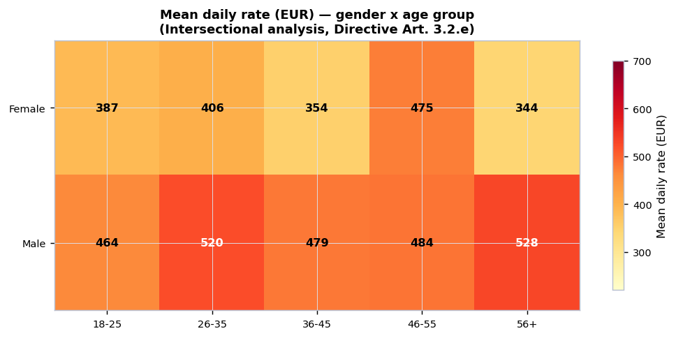

```
Saved: figures/fig4d_intersectional_heatmap.png
```

```python
age_order = ['18-25', '26-35', '36-45', '46-55', '56+']
hm_data = (
    pay.groupby(['age_group', 'gender'])['daily_rate']
    .mean()
    .unstack(level='gender')
    .reindex(age_order)
)
print("Mean daily_rate by gender x age group (Directive Art. 3.2.e):")
print(hm_data.round(0).to_string())
print()
gpg_by_age = ((hm_data['male'] - hm_data['female']) / hm_data['male'] * 100).round(1)
print("GPG by age group:")
print(gpg_by_age.to_string())

# Heatmap with imshow
hm_vals = hm_data.values.T     # shape (2 genders, 5 age groups)
genders  = list(hm_data.columns)   # ['female', 'male'] alphabetical

fig, ax = plt.subplots(figsize=(8, 3.8))
im = ax.imshow(hm_vals, aspect='auto', cmap='YlOrRd', vmin=220, vmax=700)
cb = plt.colorbar(im, ax=ax, shrink=0.85, label='Mean daily rate (EUR)')
ax.set_yticks(range(len(genders)))
ax.set_yticklabels([g.capitalize() for g in genders])
ax.set_xticks(range(len(age_order)))
ax.set_xticklabels(age_order)
ax.set_title(
    "Mean daily rate (EUR) — gender x age group\n"
    "(Intersectional analysis, Directive Art. 3.2.e)"
)
for j in range(len(age_order)):
    for i in range(len(genders)):
        val = hm_vals[i, j]
        if not np.isnan(val):
            ax.text(j, i, f'{val:.0f}',
                    ha='center', va='center', fontsize=9, fontweight='bold',
                    color='white' if val > 500 else 'black')
plt.tight_layout()
plt.savefig('figures/fig4d_intersectional_heatmap.png', dpi=150, bbox_inches='tight')
plt.show()
print("Saved: figures/fig4d_intersectional_heatmap.png")
```

**Note:** The female 46-55 cohort shows an anomalously high mean daily rate in this simulated dataset, likely reflecting small sample size in that cell combined with role concentration effects. This is a simulation artefact.

Real-world data consistently shows the gender pay gap **widens with age** — the **'scissors effect'** documented in EAO 2024 — as male pay accelerates through mid-career while female pay stagnates due to caring responsibilities and reduced negotiating power. The intersectional analysis in a real dataset would require a minimum cell size check (k >= 15 per cell) before publication, and anomalous cells would be flagged or suppressed following Eurostat cell-suppression rules.

## Section 5 — Policy Visualisations

Five publication-ready charts for trade union audiences, public funding bodies, and European Commission reporting. Each chart has a title and an interpretive subtitle written in plain English. All figures saved to `figures/`.

[figure not shown]

```
Saved: figures/fig5a_heatmap_role_contract.png
```

```python
# ---- 5a: Heatmap — role x contract_type, colour = GPG% ----
# CORRECTION 2: add asterisks for small-sample cells (< 15 obs per gender)

pivot_gpg = (
    pay.groupby(['role', 'contract_type', 'gender'])['daily_rate']
    .mean()
    .unstack('gender')
    .assign(gpg_pct=lambda x: (x['male'] - x['female']) / x['male'] * 100)
    ['gpg_pct']
    .unstack('contract_type')
)

# Count observations per gender per cell — flag if either gender < 15
cnt_m = (
    pay[pay['gender'] == 'male']
    .groupby(['role', 'contract_type'])['daily_rate'].count()
    .unstack('contract_type')
    .reindex(index=pivot_gpg.index, columns=pivot_gpg.columns)
)
cnt_f = (
    pay[pay['gender'] == 'female']
    .groupby(['role', 'contract_type'])['daily_rate'].count()
    .unstack('contract_type')
    .reindex(index=pivot_gpg.index, columns=pivot_gpg.columns)
)
small_cell = (cnt_m.fillna(0) < 15) | (cnt_f.fillna(0) < 15)

# Reorder columns for clarity
ct_order = ['permanent', 'fixed_term', 'intermittent', 'freelance_cache']
ct_present = [c for c in ct_order if c in pivot_gpg.columns]
pivot_gpg  = pivot_gpg[ct_present]
small_cell = small_cell[ct_present]

fig, ax = plt.subplots(figsize=(9, 5.8))
im = ax.imshow(pivot_gpg.values, aspect='auto', cmap='RdYlGn_r', vmin=0, vmax=35)
cb = plt.colorbar(im, ax=ax, shrink=0.88, label='Unadjusted GPG (%)')
ax.set_xticks(range(len(pivot_gpg.columns)))
ax.set_xticklabels(pivot_gpg.columns, rotation=20, ha='right')
ax.set_yticks(range(len(pivot_gpg.index)))
ax.set_yticklabels(pivot_gpg.index)

for i in range(len(pivot_gpg.index)):
    for j in range(len(pivot_gpg.columns)):
        val = pivot_gpg.iloc[i, j]
        if pd.isna(val):
            # CORRECTION 2: label blank cells as n/a instead of leaving white
            ax.text(j, i, 'n/a', ha='center', va='center',
                    fontsize=8, color='#AAAAAA', style='italic')
        else:
            flag = '*' if small_cell.iloc[i, j] else ''
            label = f'{val:.0f}%{flag}'
            ax.text(j, i, label, ha='center', va='center',
                    fontsize=8.5, fontweight='bold',
                    color='white' if val > 22 else 'black')

ax.set_title(
    "Gender Pay Gap (%) by Role and Contract Type\n"
    "Subtitle: Freelance (cachet) contracts in creative above-the-line roles "
    "show the largest gaps",
    pad=10
)

# Note for asterisked cells (placed below axes, clipping disabled)
note5a = (
    "* Cells marked * have fewer than 15 observations per gender group and should be\n"
    "interpreted with caution. Negative values indicate women earn more than men in\n"
    "that cell — likely a small-sample artefact rather than a structural finding."
)
ax.text(0.0, -0.14, note5a, fontsize=7, color=MUTED,
        ha='left', va='top', transform=ax.transAxes, clip_on=False,
        style='italic')

plt.tight_layout()
plt.savefig('figures/fig5a_heatmap_role_contract.png', dpi=150, bbox_inches='tight')
plt.show()
print("Saved: figures/fig5a_heatmap_role_contract.png")
```

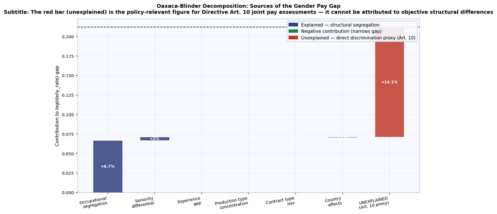

```
Saved: figures/fig5b_oaxaca_policy.png
```

```python
# ---- 5b: Oaxaca-Blinder waterfall — policy version ----
# Uses ob_contribs and total_gap from Section 3

policy_labels = {
    'role':             'Occupational\nsegregation',
    'seniority':        'Seniority\ndifferential',
    'experience_years': 'Experience\ngap',
    'production_type':  'Production type\nconcentration',
    'contract_type':    'Contract type\nmix',
    'country':          'Country\neffects',
    'unexplained':      'UNEXPLAINED\n(Art. 10 proxy)',
}

p_keys = list(policy_labels.keys())
p_vals = [ob_contribs[k] for k in p_keys]
p_labs = [policy_labels[k] for k in p_keys]

p_running = 0.0
p_bottoms = []
for v in p_vals:
    p_bottoms.append(p_running)
    p_running += v

p_colors = [
    RED  if k == 'unexplained' else
    BLUE if v >= 0             else
    GREEN
    for k, v in zip(p_keys, p_vals)
]

fig, ax = plt.subplots(figsize=(10, 5.8))
bars_p = ax.bar(p_labs, p_vals, bottom=p_bottoms,
                color=p_colors, alpha=0.85, width=0.62,
                zorder=3, edgecolor='white', linewidth=0.6)
ax.axhline(total_gap, color=NAVY, linestyle='--', linewidth=1.2, zorder=4,
           label=f'Total gap: {total_gap*100:.1f}%')
ax.axhline(0, color='black', linewidth=0.7, zorder=2)

# CORRECTION 4 (policy version): label ALL bars including small country effects
for bar, val, bot in zip(bars_p, p_vals, p_bottoms):
    mid_y = bot + val / 2
    lbl = f'{val*100:+.1f}%' if abs(val) >= 0.01 else '<1%'
    ax.text(bar.get_x() + bar.get_width() / 2, mid_y,
            lbl, ha='center', va='center',
            fontsize=7.5, fontweight='bold', color='white', zorder=5)

ep = mpatches.Patch(color=BLUE,  label='Explained — structural segregation')
np_ = mpatches.Patch(color=GREEN, label='Negative contribution (narrows gap)')
up = mpatches.Patch(color=RED,   label='Unexplained — direct discrimination proxy (Art. 10)')
ax.legend(handles=[ep, np_, up], loc='upper right', fontsize=8.5)

ax.set_title(
    "Oaxaca-Blinder Decomposition: Sources of the Gender Pay Gap\n"
    "Subtitle: The red bar (unexplained) is the policy-relevant figure for "
    "Directive Art. 10 joint pay assessments — it cannot be attributed to "
    "objective structural differences",
    pad=10
)
ax.set_ylabel("Contribution to log(daily_rate) gap")
plt.xticks(rotation=10, ha='right')
plt.tight_layout()
plt.savefig('figures/fig5b_oaxaca_policy.png', dpi=150, bbox_inches='tight')
plt.show()
print("Saved: figures/fig5b_oaxaca_policy.png")
```

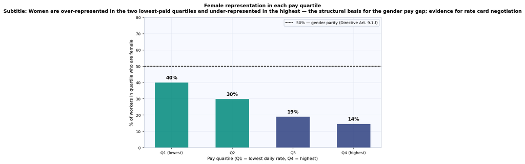

```
Saved: figures/fig5c_quartiles_policy.png
```

```python
# ---- 5c: Quartile distribution — policy version ----
# Reuses qf from Section 1c

fig, ax = plt.subplots(figsize=(7.5, 4.8))
bar_cols_q = [FEMALE_C, FEMALE_C, BLUE, BLUE]
bars_q = ax.bar(qf['quartile'], qf['pct_female'],
                color=bar_cols_q, alpha=0.85, width=0.55, zorder=3)
ax.axhline(50, color='black', linestyle='--', linewidth=1.2,
           label='50% — gender parity (Directive Art. 9.1.f)', zorder=4)
ax.set_ylim(0, 80)
ax.set_title(
    "Female representation in each pay quartile\n"
    "Subtitle: Women are over-represented in the two lowest-paid quartiles "
    "and under-represented in the highest — the structural basis for the "
    "gender pay gap; evidence for rate card negotiation",
    pad=10
)
ax.set_ylabel("% of workers in quartile who are female")
ax.set_xlabel("Pay quartile (Q1 = lowest daily rate, Q4 = highest)")
for bar, val in zip(bars_q, qf['pct_female']):
    ax.text(bar.get_x() + bar.get_width() / 2, bar.get_height() + 1.5,
            f'{val:.0f}%', ha='center', va='bottom', fontsize=10, fontweight='bold')
ax.legend(loc='upper right')
plt.tight_layout()
plt.savefig('figures/fig5c_quartiles_policy.png', dpi=150, bbox_inches='tight')
plt.show()
print("Saved: figures/fig5c_quartiles_policy.png")
```